# Predicting Movie Performance

# Introduction

# 1. Setting Up The Data

Start by downloading the data set from [links](https://www.kaggle.com/tmdb/tmdb-movie-metadata). This data set will have two CSV files, we want to use the one named “tmdb_5000_movies.CSV”. There are a lot of unecessary and ugly columns so we are going to select the budget, revenue, vote_average, and original_title columns I also add a column called profit for the profit of the movie (Revenue - Budget), this ensures that we are using values for how much money a movie makes that is relative to that movie.

```r
library(tidyverse)
options(warn=-1)

movies_raw <- read_csv("tmdb_5000_movies.csv")
movies_clean <- movies_raw %>%
  select(original_title, budget, revenue, vote_average, release_date)%>%
  filter(budget > 100)%>%
  filter(revenue > 0)%>%
  mutate(profit = revenue - budget)



movies_clean
```

```
## # A tibble: 3,218 x 6
##    original_title         budget revenue vote_average release_date  profit
##    <chr>                   <int>   <dbl>        <dbl> <date>         <dbl>
##  1 Avatar                 2.37e8  2.79e9         7.20 2009-12-10    2.55e9
##  2 Pirates of the Carib~  3.00e8  9.61e8         6.90 2007-05-19    6.61e8
##  3 Spectre                2.45e8  8.81e8         6.30 2015-10-26    6.36e8
##  4 The Dark Knight Rises  2.50e8  1.08e9         7.60 2012-07-16    8.35e8
##  5 John Carter            2.60e8  2.84e8         6.10 2012-03-07    2.41e7
##  6 Spider-Man 3           2.58e8  8.91e8         5.90 2007-05-01    6.33e8
##  7 Tangled                2.60e8  5.92e8         7.40 2010-11-24    3.32e8
##  8 Avengers: Age of Ult~  2.80e8  1.41e9         7.30 2015-04-22    1.13e9
##  9 Harry Potter and the~  2.50e8  9.34e8         7.40 2009-07-07    6.84e8
## 10 Batman v Superman: D~  2.50e8  8.73e8         5.70 2016-03-23    6.23e8
## # ... with 3,208 more rows
```

## Cleaning it up a bit

The data is almost clean, however; the budget, revenue, and profits are all very large numbers. So I am going to add another column all profit_factor. This will be calculated by Revenue/Budget. This will give much smaller and easier to read numbers We only want to examine the release month of the movie, so we grab a substring of the raw release date and treat it as a numeric for easier use later on. I create a bionmial column to see if a movie has a good profit_factor, which is just a little bit above the profit_factor mean of 12. I do the same for a good_rating of a movie, which is about 1 standard deviation above the mean of 6.

```r
movies_clean$profit <- ifelse(movies_clean$profit < 0, 0, movies_clean$profit)
movies_clean <- movies_clean %>%
  mutate(profit_factor = revenue/budget) %>%
  mutate(release_month = as.numeric(substr(release_date,6,7)))%>%
    mutate(good_profit = ifelse(profit_factor > 15, 1,0))%>%
    mutate(good_rating = ifelse(vote_average > 7,1,0))

movies_clean
```

```
## # A tibble: 3,218 x 10
##    original_title         budget revenue vote_average release_date  profit
##    <chr>                   <int>   <dbl>        <dbl> <date>         <dbl>
##  1 Avatar                 2.37e8  2.79e9         7.20 2009-12-10    2.55e9
##  2 Pirates of the Carib~  3.00e8  9.61e8         6.90 2007-05-19    6.61e8
##  3 Spectre                2.45e8  8.81e8         6.30 2015-10-26    6.36e8
##  4 The Dark Knight Rises  2.50e8  1.08e9         7.60 2012-07-16    8.35e8
##  5 John Carter            2.60e8  2.84e8         6.10 2012-03-07    2.41e7
##  6 Spider-Man 3           2.58e8  8.91e8         5.90 2007-05-01    6.33e8
##  7 Tangled                2.60e8  5.92e8         7.40 2010-11-24    3.32e8
##  8 Avengers: Age of Ult~  2.80e8  1.41e9         7.30 2015-04-22    1.13e9
##  9 Harry Potter and the~  2.50e8  9.34e8         7.40 2009-07-07    6.84e8
## 10 Batman v Superman: D~  2.50e8  8.73e8         5.70 2016-03-23    6.23e8
## # ... with 3,208 more rows, and 4 more variables: profit_factor <dbl>,
## #   release_month <dbl>, good_profit <dbl>, good_rating <dbl>
```

# 2. Exploratory Data Analysis

## Budget and Revenue

Looking at both the budget and revenue of films in a histogram does show a very similar distribution. This COULD indicate a cooreleation; but, we need to look more into that.

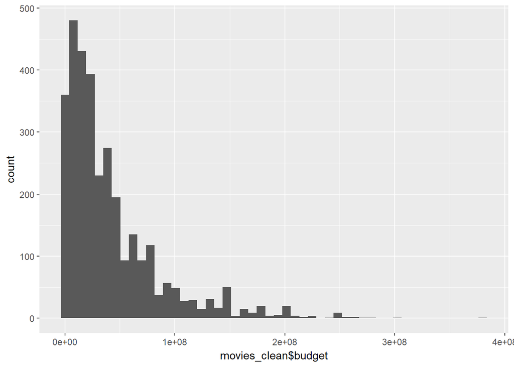

```r
library(ggplot2)
qplot(movies_clean$budget, geom="histogram", bins="50")
```

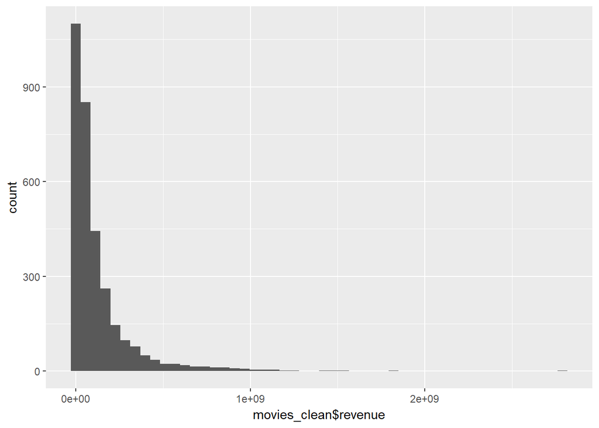

```r
qplot(movies_clean$revenue, geom="histogram", bins="50")
```

## Release Month

Now lets take a look at release months. I made a barplot with the release month on the x-axis and the movie count for that month on the y-axis. The distribution of months does seem relatively even throughout the year, expect for a small dip upwards in September, October, and December. This could be for the holiday season. Initally, I do not think there will be a coorelation

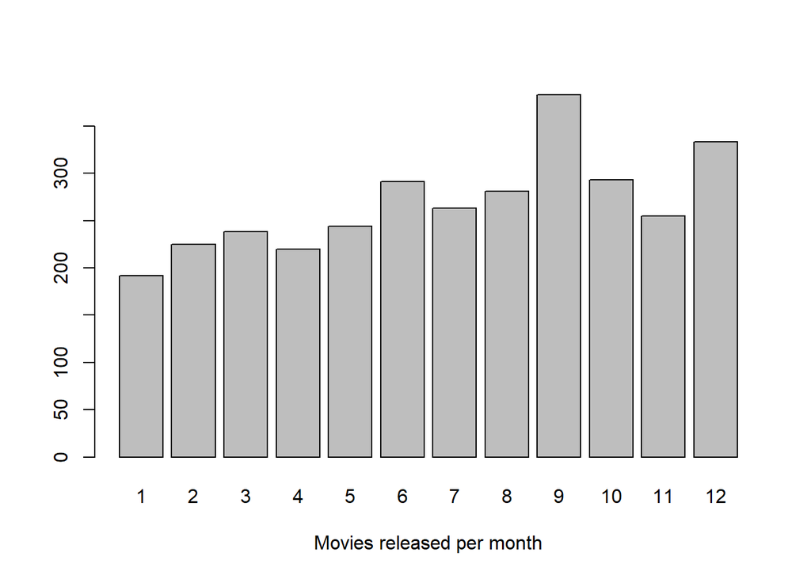

```r
barplot(table(movies_clean$release_month), xlab="Movies released per month")
```

```r
avg <- mean(movies_clean$profit_factor)
avg
```

```
## [1] 12.77347
```

```r
sdd <- sd(movies_clean$profit_factor)
sdd
```

```
## [1] 257.4889
```

## Average Rating

Now lets make a barplot examining the avreage vote of the movies

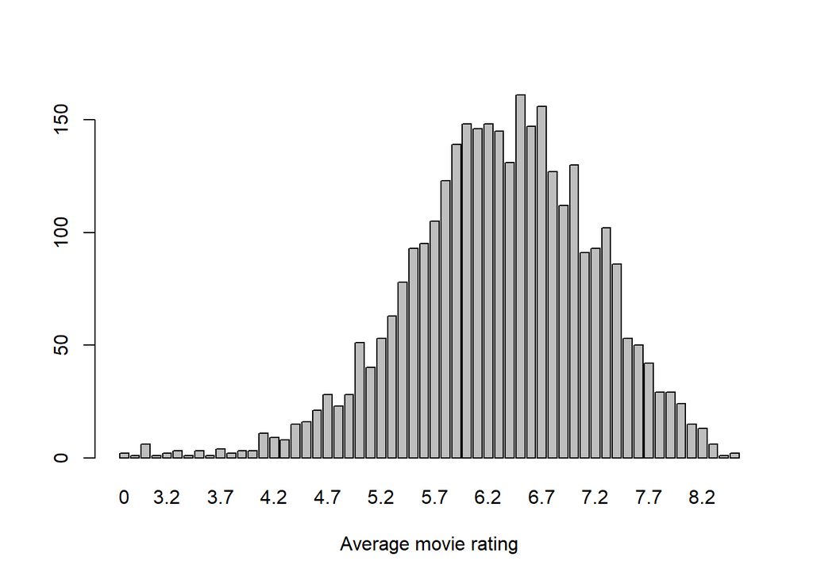

```r
barplot(table(movies_clean$vote_average), xlab="Average movie rating")
```

```r
mean_rating <- mean(movies_clean$vote_average)
sd_rating <- sd(movies_clean$vote_average)
```

# Release Month

Now lets look at variables plotted agaisnt eachother I am going to start by making a scatter plot of movie ratings across months to see if we can notice a trend

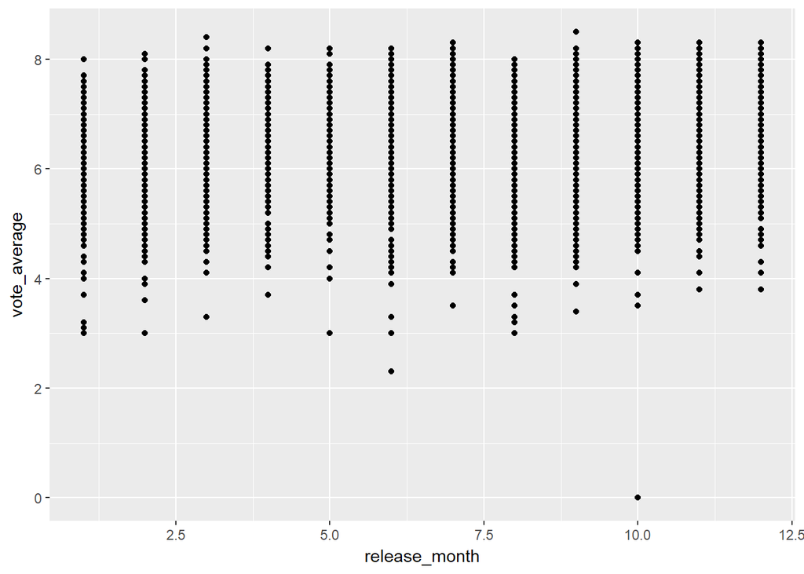

```r
movies_clean %>%
  ggplot(aes(x=release_month, y=vote_average)) + geom_point()
```

So right off the bat, it does not appear that release month affects the vote average, but we’ll get more into that when we look at the predictions

Now lets look at profit factors across months to see if we can notice a trend We temporarily filter to remove some outliters to get a better picture, then filter again to get a closer picture

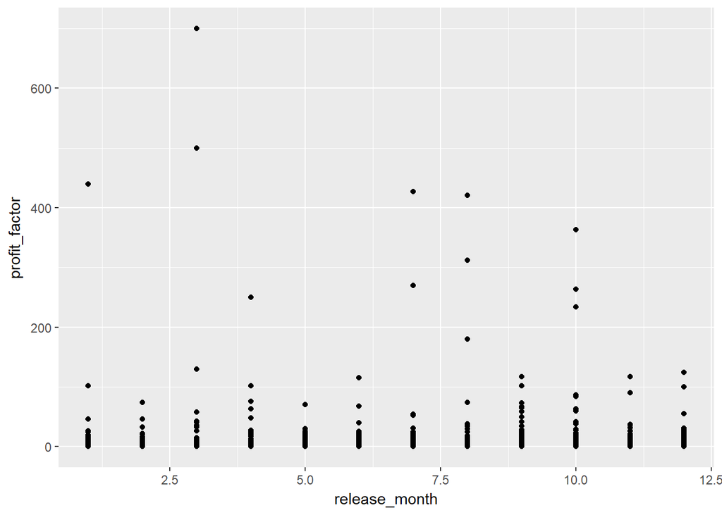

```r
movies_clean %>%
  filter(movies_clean$profit_factor<2500)%>%
  ggplot(aes(x=release_month, y=profit_factor)) + geom_point()
```

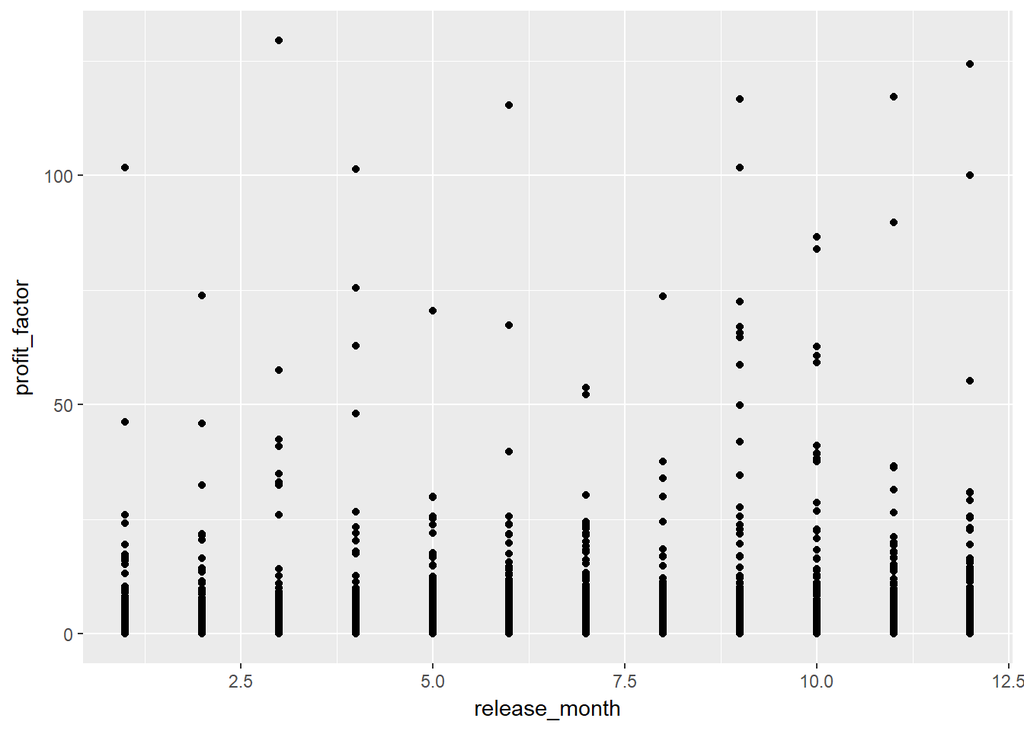

```r
movies_clean %>%
  filter(movies_clean$profit_factor<150)%>%
  ggplot(aes(x=release_month, y=profit_factor)) + geom_point()
```

Based on the second filtered graph, it does appear that most months have a pretty similar profit factor. However, appearance wise it seems there is a small increase during september. This could be due to summer blockbusters.

Now we’re going to compare budget to average rating and profit factor just like previously with release month

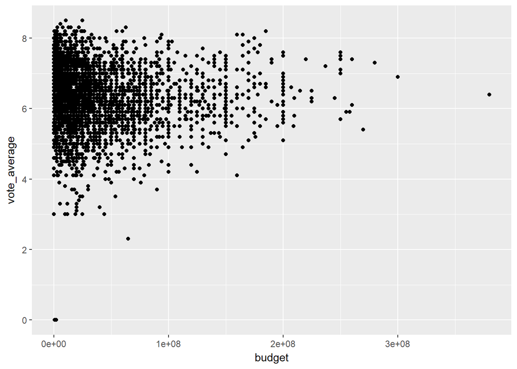

```r
movies_clean %>%
  ggplot(aes(x=budget, y=vote_average)) + geom_point()
```

Based on just the appearence, there doesn’t seem to be a trend. One important thing to note is that there are a lot more low budget movies than high budget.

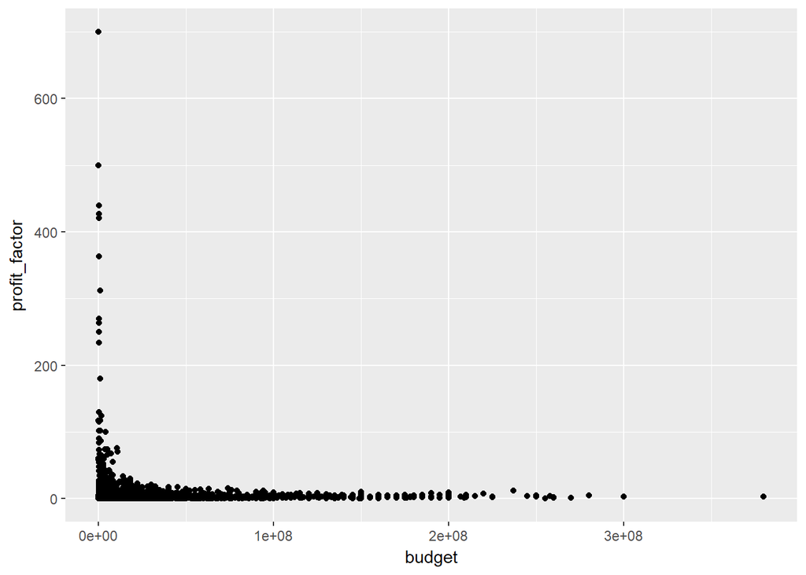

```r
movies_clean %>%
  filter(movies_clean$profit_factor<2500)%>%
  ggplot(aes(x=budget, y=profit_factor)) + geom_point()
```

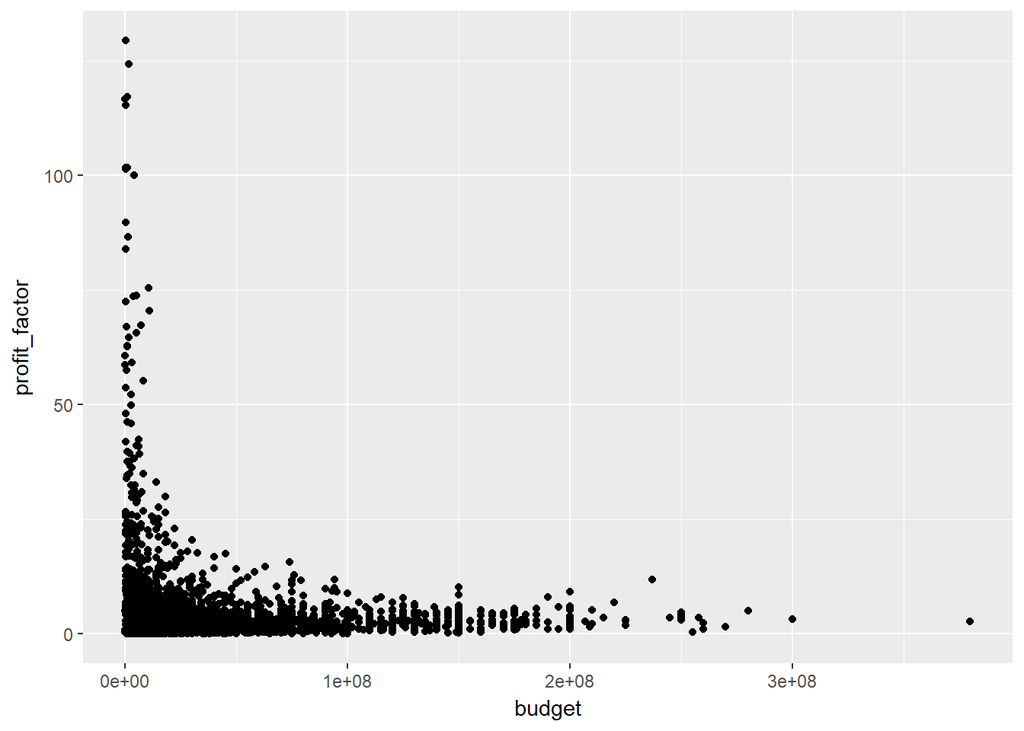

```r
movies_clean %>%
  filter(movies_clean$profit_factor<150)%>%
  ggplot(aes(x=budget, y=profit_factor)) + geom_point()
```

It does appear that lower budget movies tend to have more high profit factors.

# 3. Machine Learning

We are going to be using ML techniques in order to build a model to predict movie performance. We are going to create 3 models to predict either whether a movie has a good profit or ratings. We will make a regression model, a tree, and a random forest. Here we start with predicting if a movie will have good profit. Our predictors and release_month and budget as mentioned above

```r
library(randomForest)
library(tree)
library(caret)
testdata <- movies_clean %>%
  select(good_profit,release_month,budget)

movies_clean$profit_factor <- as.numeric(movies_clean$profit_factor)

set.seed(12345)
index <- sample(1:nrow(testdata),.5*nrow(testdata),replace=F)
traindata <- testdata[index,]
traindata$good_profit <- as.numeric(traindata$good_profit)
validdata <- testdata[-index,]

logis_fit <- glm(good_profit~., data = traindata, family ="binomial")
logis_pred <- ifelse(predict(logis_fit, newdata=validdata,type ="response")>0.5,1,0)
logis_error <- mean(validdata$good_profit != logis_pred)
logis_error
```

```
## [1] 0.05966439
```

```r
traindata$good_profit <- as.factor(traindata$good_profit)
validdata$good_profit <- as.factor(validdata$good_profit)

tree_fit <- tree(good_profit~., data = traindata)
pruned_tree <-prune.tree(tree_fit, best = 3)

tree_pred <- predict(pruned_tree, newdata=validdata, type = "class")
tree_error <- mean(validdata$good_profit != tree_pred)

tree_error
```

```
## [1] 0.05220634
```

```r
library(ROCR)
library(pROC)
sampels <- sample(nrow(movies_clean), nrow(movies_clean)*.5)
forest <- train(good_profit~., data = traindata)
```

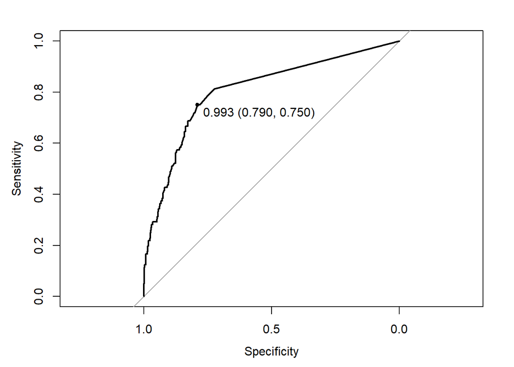

```r
result_pred <- predict(forest, validdata, type = "prob")
result_roc <- roc(validdata$good_profit, result_pred$"0")
plot(result_roc , print.thres="best", print.thres.best.method="closest.topleft")
```

```r
result.coords <- coords(result_roc, "best", best.method="closest.topleft", ret=c("threshold", "accuracy"))
print(result.coords)
```

```
## threshold  accuracy
## 0.9930000 0.7874456
```

```r
auc(result_roc)
```

```
## Area under the curve: 0.8063
```

## Good Rating

```r
library(randomForest)
library(tree)
library(caret)
testdata <- movies_clean %>%
  select(good_rating,release_month,budget)


set.seed(12345)
index <- sample(1:nrow(testdata),.5*nrow(testdata),replace=F)
traindata <- testdata[index,]
traindata$good_rating <- as.numeric(traindata$good_rating)
validdata <- testdata[-index,]

logis_fit <- glm(good_rating~., data = traindata, family ="binomial")
logis_pred <- ifelse(predict(logis_fit, newdata=validdata,type ="response")>0.5,1,0)
logis_error <- mean(validdata$good_rating != logis_pred)
logis_error
```

```
## [1] 0.1982598
```

```r
traindata$good_rating <- as.factor(traindata$good_rating)
validdata$good_rating <- as.factor(validdata$good_rating)

tree_fit <- tree(good_rating~., data = traindata)
pruned_tree <-prune.tree(tree_fit, best = 3)

tree_pred <- predict(pruned_tree, newdata=validdata, type = "class")
tree_error <- mean(validdata$good_rating != tree_pred)

tree_error
```

```
## [1] 0.1982598
```

```r
library(ROCR)
library(pROC)
sampels <- sample(nrow(movies_clean), nrow(movies_clean)*.5)
forest <- train(good_rating~., data = traindata)
```

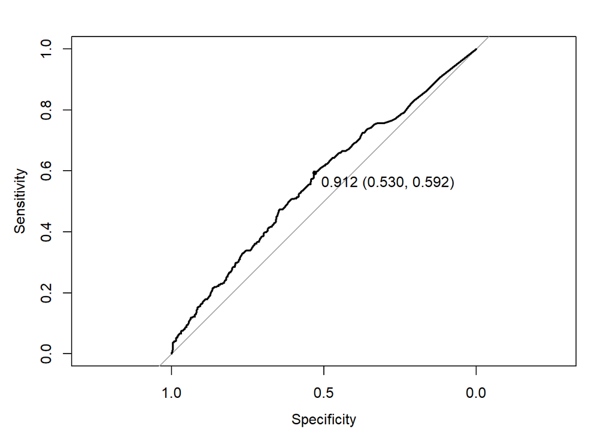

```r
result_pred <- predict(forest, validdata, type = "prob")
result_roc <- roc(validdata$good_rating, result_pred$"0")
plot(result_roc , print.thres="best", print.thres.best.method="closest.topleft")
```

```r
result.coords <- coords(result_roc, "best", best.method="closest.topleft", ret=c("threshold", "accuracy"))
print(result.coords)
```

```
## threshold  accuracy
##  0.912000  0.542573
```

```r
auc(result_roc)
```

```
## Area under the curve: 0.5679
```

## Analysis of predicting rating

The error ratings for both the regression model and the tree are both 0.199, which is far more than 0.05. The AUC for the random Forest is unfortunately way too low too. As a result, we cannot use any of our predictors to see if a movie will have a good rating or not

## What have we learned

Overall, we learned that we cannot predict a movies’ profit factor or rating based on the month it was released and the budget. Predicting profit factor is close, but not close enough. With more tests we might be able to find an accurate model. So what is the best movie to see? Whatever movie you are interested in! You shouldn’t care about profit or ratings, go watch what is interesting to you!

[output not shown]